# Homework 5 Solution

## Problem 1 -- Nonconvex Quadratics

Suppose you have the constraint:

$2x^2 + y^2+ z^2 + 3xy - xz + 2yz \leq 0 \quad\quad$ (1)

(a) Write constraint (1) in the standard form $v^TQv\leq 0$ where $Q$ is a symmetric matrix. What is $Q$ and what is $v$?

(b) This constraint is not convex (i.e., the set of points satisfying the constraint is not an ellipsoid). Explain why this is the case. *Hint*: You can perform an orthogonal decomposition of a symmetric matrix $Q$ in Julia like this:

## (a)

\begin{align*} v &= \begin{bmatrix} x \\ y \\ z \end{bmatrix} & Q &= \begin{bmatrix} 2 & 3 & -1 \\ 0& 1 & 0\\ 0 & 2& 1\end{bmatrix} & Q &= \begin{bmatrix} 2 & 1.5 & -0.5 \\ 1.5 & 1 & 1\\ -0.5 & 1 & 1\end{bmatrix} & \end{align*}

## (b)

```julia
using LinearAlgebra
Q = [2   1.5  -0.5
     1.5 1    1
    -0.5 1    1]
(L,U) = (eigvals(Q),eigvecs(Q)) # L is the vector of eigenvalues and U is orthogonal
U * Diagonal(L) * U' # this is equal to Q (as long as Q was symmetric to begin with)
```

```
3×3 Matrix{Float64}:
  2.0  1.5  -0.5
  1.5  1.0   1.0
 -0.5  1.0   1.0
```

```julia
L
```

```
3-element Vector{Float64}:
 -0.7717848741953769
  1.671965737371683
  3.099819136823694
```

After computing the eigenvalues, if any of them is negative, then the matrix Q is not positive semi-definite and the constraint is not convex. If all eigenvalues are non-negative (i.e., they are either positive or zero), then the matrix Q is positive semi-definite and the constraint is convex. In this case, one of the eigenvalues is negative so Q is not positive semi-definite and the constraint is not convex.

(c) We can write constraint (1) in norm format as follows:

$‖Av‖_2^2−‖Bv‖_2^2\leq 0 \quad\quad$ (2)

Find matrices $A$ and $B$ that make this constraint equivalent to (1).

(d) Explain how to find $(x, y, z)$ that satisfy the above constraint but make $2x^2+ y^2 + z^2$ arbitrarily large.

## (c)

```julia
L
```

```
3-element Vector{Float64}:
 -0.7717848741953769
  1.671965737371683
  3.099819136823694
```

The first eigenvalue is negative and the other two are positive

```julia
A_in_progress = U[:, 2:3]* Diagonal(L)[2:3, 2:3]*U[:,2:3]'
```

```
3×3 Matrix{Float64}:
  2.1745    1.24242   -0.305375
  1.24242   1.38021    0.712716
 -0.305375  0.712716   1.21707
```

```julia
B_in_progress = U[:, 1]* Diagonal(-L)[1, 1]*U[:,1]'
```

```
3×3 Matrix{Float64}:
  0.174504  -0.257582   0.194625
 -0.257582   0.380214  -0.287284
  0.194625  -0.287284   0.217067
```

```julia
A = A_in_progress*(1/2)
```

```
3×3 Matrix{Float64}:
  1.08725   0.621209  -0.152687
  0.621209  0.690107   0.356358
 -0.152687  0.356358   0.608534
```

```julia
B = B_in_progress*(1/2)
```

```
3×3 Matrix{Float64}:
  0.0872518  -0.128791   0.0973127
 -0.128791    0.190107  -0.143642
  0.0973127  -0.143642   0.108534
```

## (d)

2x² + y² + z² + 3xy - xz + 2yz ≤ 0  
y² + z² + (3x)y - xz + 2yz ≤ -2x²  
Consider that we make x very large (i.e., x → ∞), which makes 2x² + y² + z² also very large. To maintain the condition, we need y(3x + 2z) - xz to be even larger and negative to offset the positive y² + z².  
A simple way to achieve this would be to have y = -x and z = x (since we are dealing with real numbers, negative values are allowed). This gives us:  
(-x)² + x² - (-x)(3x + 2x) - x² ≤ -2x²  
This simplifies to:-3x² ≤ -2x²  
Since x is very large and positive, -3x² will be very large and negative, and it will indeed be less than or equal to -2x². Thus, the inequality is satisfied. So, we can set x = a very large number, and then set y = -x, z = x. This will satisfy the given constraint while making the expression 2x² + y² + z² arbitrarily large.

## Problem 2 -- Geometric Programming

Fizzy Water, Inc. is designing a pipe that disinfects their water before it is packaged. The pipe is designed to heat the water to $T$ (degrees above ambient temperature). The pipe has a fixed length and circular cross section with radius $r$. The pipe is wrapped in a layer of material with thickenss $w$ (much smaller than $r$) for insulation to minimize heat loss. The design variables for the pipe are $T, r,$ and $w$.

Heat loss can be converted to energy cost and is roughly equal to $(\alpha_1Tr)/w$ for some constant $\alpha_1$. The cost of the pipe is approximately proportional to the total material used: $\alpha_2r$ for a constant $\alpha_2$. The insulation cost, similarly,is porportional to the total insulation material used, or roughly $\alpha_3rw$ for a constant $\alpha_3$. The total cost of constructing and using the pipe is the sum of these three costs.

Fizzy Water wants to maximize the total heat flow through the pipe, which is proportional to the velocity of the water through the pipe. This value can be approximated by $\alpha_4Tr^2$ for a constant $\alpha_4$. All $\alpha$ constants and all variables $T, r, w$ are strictly positive.

The problem Fizzy Water wants you to help them solve is to maximize the total heat flow through the pipe, subject to their budget $C_{\max}$ which is an upper bound on total cost. They also have the following constraints:

- $T_{\min} \le T \le T_{\max}$
- $r_{\min} \le r \le r_{\max}$
- $w_{\min} \le w \le w_{\max}$
- $w \le 0.1r$

(a) Express this problem as a geometric program, and convert it into a convex optimization problem.

(b) Consider a simple instance of this problem where $C_{\max} = 100$ and all $\alpha_i$ values equal 1. Assume for simplicity that every variable ($T,r,w$) has a lower bound of 1 and no upper bound. Solve this problem using JuMP. Use the Ipopt solver (or any other solver that can solve convex optimization problems) and the "@NLconstraint(...)" command to specify any nonlinear constraints. What are the optimal $T, r$, and $w$?

## (a)

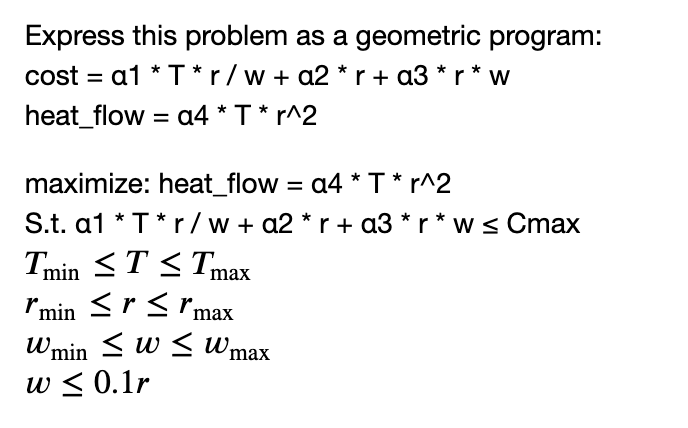

convert it into a convex optimization problem.  
y = log(T)  
x = log(r)  
z = log(w)  
Objective function: log(heat_flow) = log(α4) + y + 2x  
Constraints: log(α1) + y + x - z + log(α2) + x + log(α3) + x + z ≤ log(Cmax)  
log(Tmin) ≤ y ≤ log(Tmax)  
log(rmin) ≤ x ≤ log(rmax)  
log(wmin) ≤ z ≤ log(wmax)  
z ≤ log(0.1) + x

## (b)

```julia
using JuMP, Ipopt

# Create a new model, specifying the Ipopt solver
model = Model(Ipopt.Optimizer)

# Define the variables
@variable(model, T >= 1)
@variable(model, r >= 1)
@variable(model, w >= 1)

# Define the constraints
@NLconstraint(model, T * r / w + r + r * w <= 100)
@NLconstraint(model, w <= 0.1 * r)

# Define the objective function to maximize heat flow
@NLobjective(model, Max, T * r^2)

# Solve the optimization problem
optimize!(model)

# Get the optimal solution
T_opt = value(T)
r_opt = value(r)
w_opt = value(w)

println("Optimal T: ", T_opt)
println("Optimal r: ", r_opt)
println("Optimal w: ", w_opt)
```

```
This program contains Ipopt, a library for large-scale nonlinear optimization.
 Ipopt is released as open source code under the Eclipse Public License (EPL).
         For more information visit https://github.com/coin-or/Ipopt

This is Ipopt version 3.14.13, running with linear solver MUMPS 5.6.0.

Number of nonzeros in equality constraint Jacobian...:        0
Number of nonzeros in inequality constraint Jacobian.:        5
Number of nonzeros in Lagrangian Hessian.............:        9

Total number of variables............................:        3
                     variables with only lower bounds:        3
                variables with lower and upper bounds:        0
                     variables with only upper bounds:        0
Total number of equality constraints.................:        0
Total number of inequality constraints...............:        2
        inequality constraints with only lower bounds:        0
   inequality constraints with lower and upper bounds:        0
        inequality constraints with only upper bounds:        2

iter    objective    inf_pr   inf_du lg(mu)  ||d||  lg(rg) alpha_du alpha_pr  ls
   0  1.0303010e+00 9.09e-01 8.92e-01  -1.0 0.00e+00    -  0.00e+00 0.00e+00   0
   1  1.0406911e+00 8.99e-01 4.79e+00  -1.0 6.45e-01    -  1.09e-01 2.17e-02h  1
   2  1.3899158e+02 0.00e+00 2.11e+02  -1.0 2.86e+01    -  3.13e-02 1.00e+00f  1
   3  1.4087259e+02 0.00e+00 2.09e+02  -1.0 1.56e+01   0.0 8.45e-02 1.16e-02f  1
   4  1.5069820e+02 0.00e+00 9.51e+01  -1.0 3.85e+00   0.4 1.00e+00 6.19e-01f  1
   5  3.0114939e+02 0.00e+00 1.68e+02  -1.0 1.37e+01  -0.1 1.66e-02 1.00e+00f  1
   6  3.3968897e+02 0.00e+00 1.26e+02  -1.0 7.59e+00   0.4 1.00e+00 2.54e-01f  1
   7  1.3735597e+03 0.00e+00 1.14e+02  -1.0 3.82e+01  -0.1 2.13e-01 1.00e+00f  1
   8  1.6784796e+03 1.61e+00 3.53e+01  -1.0 1.80e+01   0.3 1.00e+00 6.57e-01f  1
   9  1.6827107e+03 1.73e+00 1.58e+02  -1.0 7.39e+01  -0.2 1.00e+00 1.60e-03f  1
iter    objective    inf_pr   inf_du lg(mu)  ||d||  lg(rg) alpha_du alpha_pr  ls
  10  1.6212321e+03 9.55e-03 7.69e-01  -1.0 3.85e-01    -  1.00e+00 1.00e+00h  1
  11  1.6209526e+03 0.00e+00 4.35e-05  -1.7 4.69e-03    -  1.00e+00 1.00e+00h  1
  12  1.6209920e+03 0.00e+00 1.20e-06  -3.8 5.54e-04    -  1.00e+00 1.00e+00f  1
  13  1.6209923e+03 0.00e+00 5.32e-11  -5.7 4.15e-06    -  1.00e+00 1.00e+00h  1
  14  1.6209923e+03 0.00e+00 2.95e-13  -8.6 5.15e-08    -  1.00e+00 1.00e+00h  1

Number of Iterations....: 14

                                   (scaled)                 (unscaled)
Objective...............:  -1.6209922870195464e+03    1.6209922870195464e+03
Dual infeasibility......:   2.9466425213877474e-13    2.9466425213877474e-13
Constraint violation....:   0.0000000000000000e+00    0.0000000000000000e+00
Variable bound violation:   0.0000000000000000e+00    0.0000000000000000e+00
Complementarity.........:   2.5059275813338298e-09    2.5059275813338298e-09
Overall NLP error.......:   2.5059275813338298e-09    2.5059275813338298e-09


Number of objective function evaluations             = 15
Number of objective gradient evaluations             = 15
Number of equality constraint evaluations            = 0
Number of inequality constraint evaluations          = 15
Number of equality constraint Jacobian evaluations   = 0
Number of inequality constraint Jacobian evaluations = 15
Number of Lagrangian Hessian evaluations             = 14
Total seconds in IPOPT                               = 0.524

EXIT: Optimal Solution Found.
Optimal T: 4.526926365865797
Optimal r: 18.92294639069403
Optimal w: 1.8922946490554067
```